# Data-Driven Stock Analysis 2024–2025

Kenet Kivimägi

### Welcome

Explore our 2024–2025 data-driven stock analysis of U.S. equities. This tool highlights operational efficiency, predicted growth, and market performance. We combine firm productivity and predictive modeling to identify stocks with high expected growth and lower risk. All data is informational only.

## Introduction

This section presents a quantitative analysis of selected U.S. stocks based on operational efficiency, investment activity, and model-based price predictions. **The author may own shares of some companies discussed in this analysis. This report is for informational purposes only and does not constitute investment advice.** Past performance does not guarantee future results. Readers should consult a licensed financial advisor before making any investment decisions.

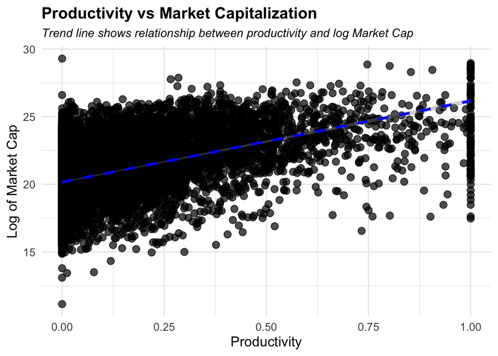

**Note:** Productivity scores are based on historical and publicly available data and do not guarantee future performance.

## Predictive Modeling

Predicts stock growth based on historical data and company metrics. The LASSO (Least Absolute Shrinkage and Selection Operator) regression helps select the most relevant features while preventing overfitting.

We create a predictive model using LASSO to estimate expected stock price growth, combining historical financial trends with operational metrics. We train this model on past years and use it to predict growth for the following year. These predictions are designed to study relationships between efficiency and stock performance.

```r
source("model_LASSO.R")
```

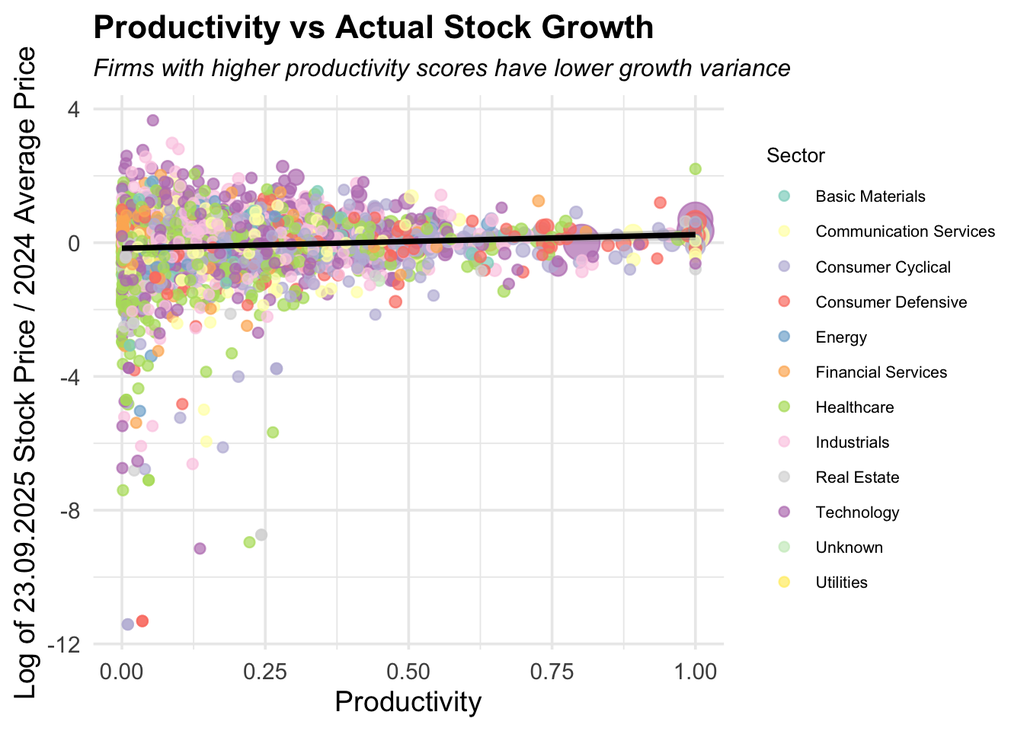

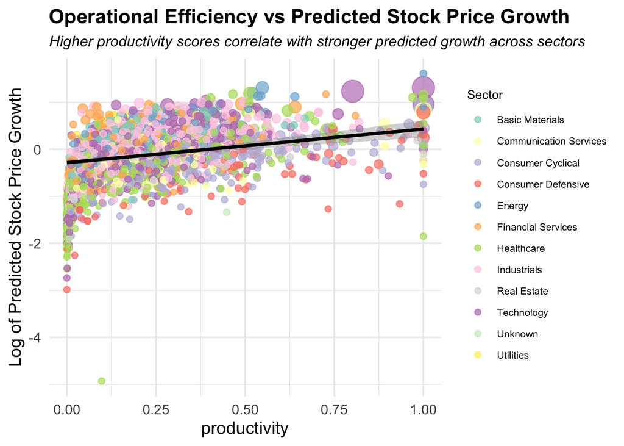

**Disclaimer:** Model outputs are projections only and should not be considered recommendations. Actual stock prices may differ significantly.

**All metrics are used for analytical purposes and do not constitute a recommendation to buy or sell any stock.**

## Composite Ranking System

1. Productivity
2. Relative valuation compared to predicted performance
3. Financial modelling

**Note:** The author may hold positions in some of the securities.